# Pavement Plots in R with ggpaver

David Williams

October 15, 2026

## Acknowledgements

- Not my idea! I’m just bringing it to R: https://github.com/ajschumacher/pavement
- DSDC Side Project Mentorship

## Why I Wanted to Do This Project

- I like R
- I like visualizing data
- I wanted to try developing a package

## My Approach

- `ggplot2` is powered by `Geom` and `Stat` objects created via the `ggproto` function
- `ggpaver` adds `GeomPavement` and `StatPavement` objects, along with `geom_pavement` and `stat_pavement` functions for use in plotting
  - The approach is similar to how `ggplot2` implements boxplots

## Just What Is a Pavement Plot Anyway?

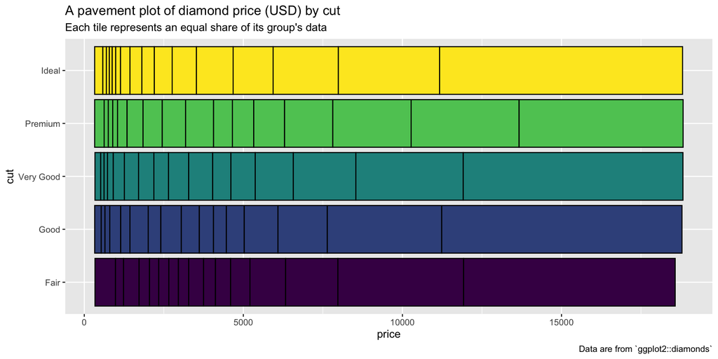

## What Does the Code Look Like?

- Enter `ggpaver`:

```r
library(ggplot2)
library(ggpaver)

ggplot(diamonds, aes(x = price, y = cut, fill = cut)) +
  geom_pavement(bins = 16, show.legend = FALSE) +
  labs(
    title = "A Pavement Plot of Diamond Price (USD) by Cut",
    subtitle = "Each Tile Represents an Equal Share of its Group's Data",
    caption = "Data are from `ggplot2::diamonds`"
  )
```

# What’s Wrong with Other Plots?

## Histograms

- Groups make bins crowded
- Easy to manipulate
- Histograms
- Code

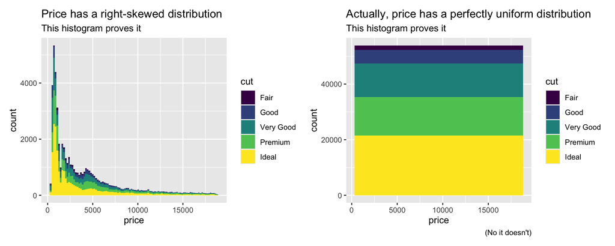

```r
library(patchwork)
hist_base <- ggplot(diamonds, aes(x = price, fill = cut))
p1 <- hist_base +
  geom_histogram(bins = 100) +
  labs(
    title = "Price has a right-skewed distribution",
    subtitle = "This histogram proves it"
  )
p2 <- hist_base +
  # With a simple change to bin number, the data's shape looks different:
  geom_histogram(bins = 1) +
  labs(
    title = "Actually, price has a perfectly uniform distribution",
    subtitle = "This histogram proves it",
    caption = "(No it doesn't)"
  )
p1 + p2
```

## Kernal Density Estimates (KDEs)

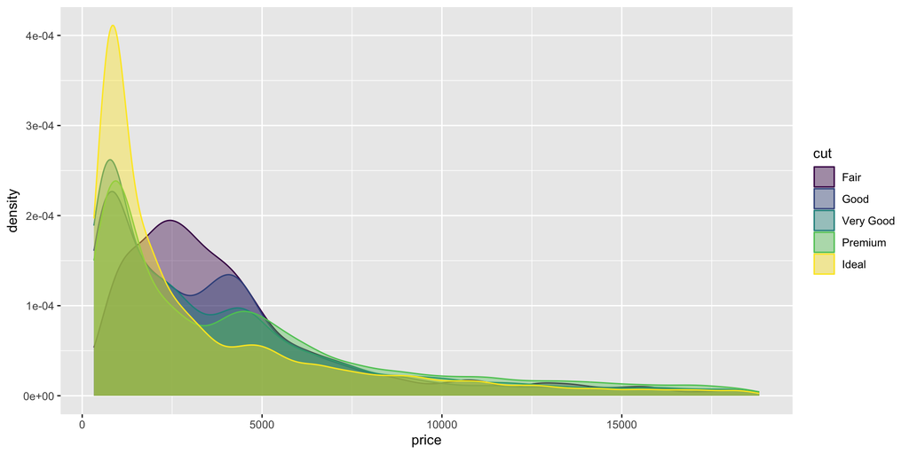

- Not necessarily intuitive to interpret
- Groups can be messy

## Boxplots

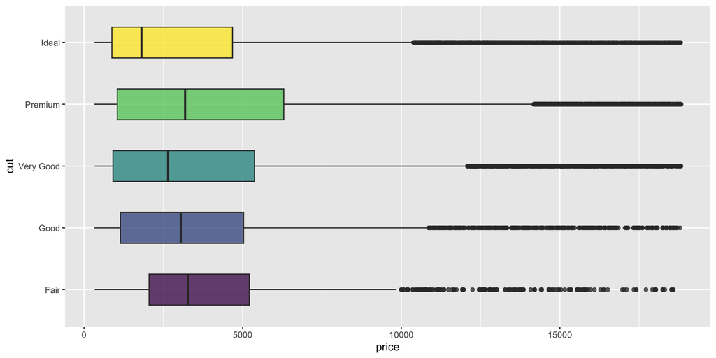

- Better than the aforementioned alternatives, but …
- Depending on the viewer’s background, it may not be obvious what the box, whiskers, and outliers each represent
- Not ideal for multimodal data—there’s a reason that they’re called *boxplots* instead of *boxes**-plots*

## Example: Bimodal Data

- Boxplot
- Code

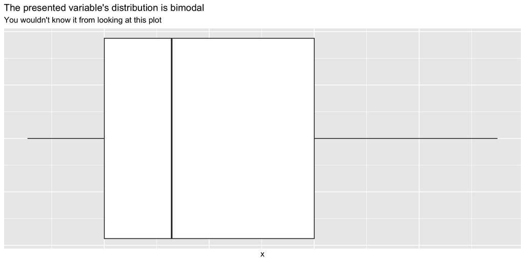

```r
set.seed(20261015)
n <- 10000
x1 <- rnorm(n, mean = 250, sd = 50)
x2 <- rnorm(n, mean = 750, sd = 100)
bimodal <- data.frame(x = c(x1, x2))
# Saving title string since I'll be using it again:
bimodal_title <- "The presented variable's distribution is bimodal"

ggplot(bimodal, aes(x = x)) +
  geom_boxplot() +
  labs(
    title = bimodal_title,
    subtitle = "You wouldn't know it from looking at this plot"
  )
```

## Pavement to the Rescue!

- Pavement Plot
- Code

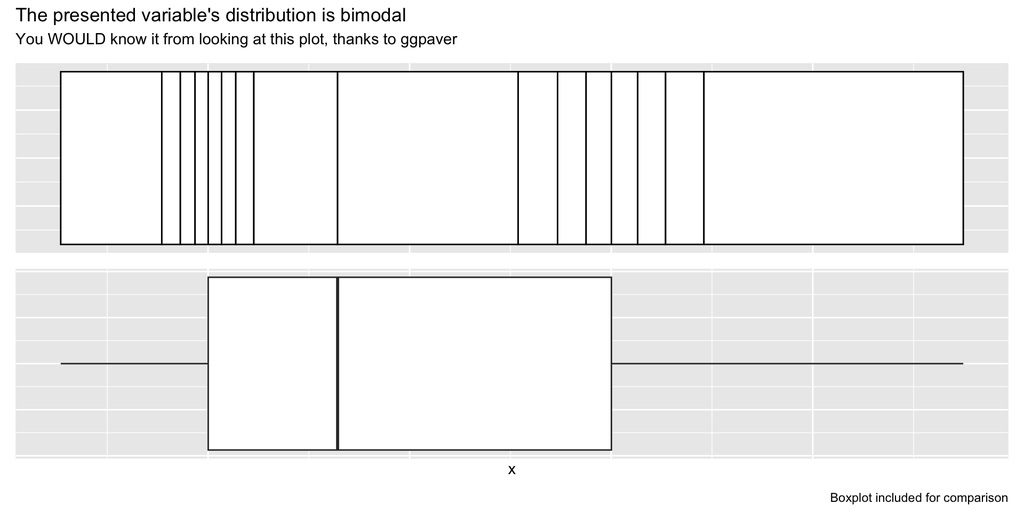

```r
pavement <- ggplot(bimodal, aes(x = x)) +
  geom_pavement(bins = 16) +
  labs(x = NULL)
box <- ggplot(bimodal, aes(x = x)) + geom_boxplot()

patchwork1 <- pavement / box
patchwork1 +
  plot_annotation(
    title = bimodal_title,
    subtitle = "You WOULD know it from looking at this plot, thanks to ggpaver",
    caption = "Boxplot included for comparison"
  )
```

## What about Violin Plots?

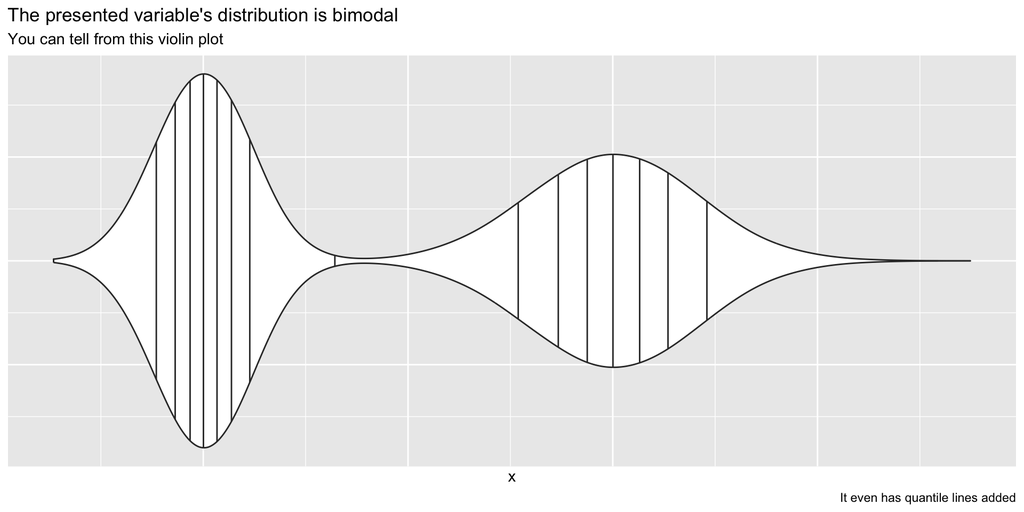

## Well…

- They trade the boxplot’s simplicity for flexibility—a good trade, but still a trade
- Pavement plots are *both simple **and** flexible*

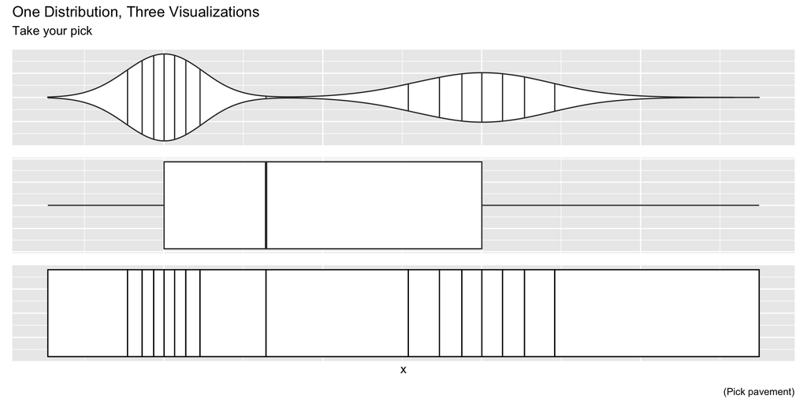

## What’s Next?

- Publish to CRAN
- Explore other visualization libraries
- Extend functionality

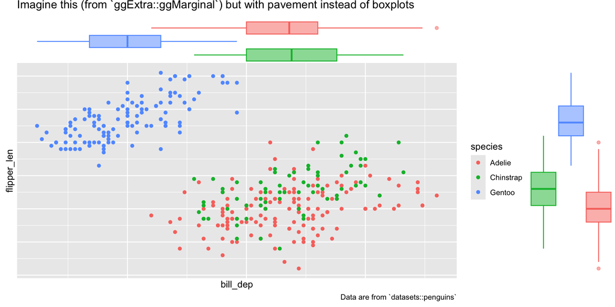

## Try it yourself

- Install the dev version in R: `pak::pak("git-dwilliams/ggpaver")`
- Check the repo out: https://github.com/git-dwilliams/ggpaver